# Analysis of US Household Incomes

Shreyas Srinath

### Introduction

The United States has routinely collected information regarding household incomes across multiple states, districts, counties and cities. This data can then be further analyzed to provide a snapshot of the state of modern American households.

By analyzing data found on Kaggle from the year 2017, I have attempted to break down a rich dataset into its constituent parts to uncover patterns, insights and interesting facts about the US as it pertains to annual incomes.

### Data

**Citation:** Golden Oak Research Group, LLC. “U.S. Income Database Kaggle”.  
**Publication:** 5, August 2017.  
**Accessed:** 13, December 2022.

The data is obtained from a report of *Golden Oak Research Group*, which has partitioned a larger dataset to be used by city planners and real estate developers.

The dataset comprises 30,000+ rows of household income data with geographical, regional and statistical indicators.

The following attributes are clearly defined:

1. id : A random row identifier (character)
2. State_Code : State identifier (character)
3. State_Name : State name (character)
4. State_ab : State Code (character)
5. County : County Name (character)
6. City : City Name (character)
7. Place : Place Name (character)
8. Type : Place Type (character). Can be:  
   -> Borough  
   -> CDP  
   -> City  
   -> Community  
   -> County  
   -> Municipality  
   -> Town  
   -> Track  
   -> Urban  
   -> Village
9. Primary : Primary Type (character)
10. Zip_Code : Zip Code (character)
11. Area_Code : Area Code (double)
12. ALand : Land Area (double)
13. AWater : Water Area (double)
14. Lat : Latitude Coordinate (double)
15. Lon : Longitude Coordinate (double)
16. Mean : Mean Household Income in $ (double)
17. Median : Median Household Income in $ (double)
18. Stddev : Standard Deviation in $ (double)
19. sum_w : Unidentified metric (double)

### Importing Libraries

I have employed the tidyverse, ggplot2, dplyr, forcats and mapview libraries for the analysis.

```r
#######################
# Importing Libraries #
#######################

library(tidyverse)
library(sf)
```

```r
library(ggplot2)
library(mapview) # Used to plot clusters geographically
library(dplyr)
library(fastDummies) # Used to generate dummy variables
library(forcats)
```

### Importing Dataset

I have used the read_csv method to import the data as it is stored in the *Comma Separated Values* format.

```r
#####################
# Importing Dataset #
#####################

dataset <- as.data.frame(read_csv("kaggle_income.csv"))
# Display first six rows
head(dataset)
```

```
##         id State_Code State_Name State_ab         County           City
## 1 01011000         01    Alabama       AL  Mobile County      Chickasaw
## 2 01011010         01    Alabama       AL Barbour County     Louisville
## 3 01011020         01    Alabama       AL  Shelby County     Columbiana
## 4 01011030         01    Alabama       AL  Mobile County        Satsuma
## 5 01011040         01    Alabama       AL  Mobile County Dauphin Island
## 6 01011050         01    Alabama       AL Cullman County        Cullman
##             Place Type Primary Zip_Code Area_Code    ALand    AWater      Lat
## 1  Chickasaw city City   place    36611       251 10894952    909156 30.77145
## 2       Clio city City   place    36048       334 26070325     23254 31.70852
## 3 Columbiana city City   place    35051       205 44835274    261034 33.19145
## 4     Creola city City   place    36572       251 36878729   2374530 30.87434
## 5  Dauphin Island Town   place    36528       251 16204185 413605152 30.25091
## 6      Dodge City Town   place    35057       256  8913021     26837 34.04541
##         Lon  Mean Median Stdev     sum_w
## 1 -88.07970 38773  30506 33101 1638.2605
## 2 -85.61104 37725  19528 43789  258.0177
## 3 -86.61562 54606  31930 57348  926.0310
## 4 -88.00944 63919  52814 47707  378.1146
## 5 -88.17127 77948  67225 54270  282.3203
## 6 -86.88267 50715  42643 35886  173.3260
```

### Tidying Dataset

I have identified a single observational row with a missing value. Since the data that is missing is qualitative, I decided to omit that row from further analysis.

```r
##########################
# Handling Missing Values#
##########################

colSums(is.na(dataset))
```

```
##         id State_Code State_Name   State_ab     County       City      Place
##          0          0          0          0          0          0          0
##       Type    Primary   Zip_Code  Area_Code      ALand     AWater        Lat
##          0          0          0          1          0          0          0
##        Lon       Mean     Median      Stdev      sum_w
##          0          0          0          0          0
```

```r
# Identify the indices for the missing value
which(is.na(dataset), arr.ind = TRUE)
```

```
##        row col
## [1,] 27548  11
```

```r
# Remove that entry from the dataset
dataset <- dataset[-27548,]
# Check for missing values
colSums(is.na(dataset))
```

```
##         id State_Code State_Name   State_ab     County       City      Place
##          0          0          0          0          0          0          0
##       Type    Primary   Zip_Code  Area_Code      ALand     AWater        Lat
##          0          0          0          0          0          0          0
##        Lon       Mean     Median      Stdev      sum_w
##          0          0          0          0          0
```

### Preliminary Analysis

This is done for understanding the dimensionality the levels for the qualitative variables and correlations for the quantiative variables.

```r
############################
# Understanding the Dataset#
############################

dim(dataset)
```

```
## [1] 32525    19
```

```r
# Dataset has 32525 rows and 19 variables

# Check Levels and Count for qualitative variables

# - State_Name
sort(unique(dataset$State_Name))
```

```
##  [1] "Alabama"              "Alaska"               "Arizona"
##  [4] "Arkansas"             "California"           "Colorado"
##  [7] "Connecticut"          "Delaware"             "District of Columbia"
## [10] "Florida"              "Georgia"              "Hawaii"
## [13] "Idaho"                "Illinois"             "Indiana"
## [16] "Iowa"                 "Kansas"               "Kentucky"
## [19] "Louisiana"            "Maine"                "Maryland"
## [22] "Massachusetts"        "Michigan"             "Minnesota"
## [25] "Mississippi"          "Missouri"             "Montana"
## [28] "Nebraska"             "Nevada"               "New Hampshire"
## [31] "New Jersey"           "New Mexico"           "New York"
## [34] "North Carolina"       "North Dakota"         "Ohio"
## [37] "Oklahoma"             "Oregon"               "Pennsylvania"
## [40] "Puerto Rico"          "Rhode Island"         "South Carolina"
## [43] "South Dakota"         "Tennessee"            "Texas"
## [46] "Utah"                 "Vermont"              "Virginia"
## [49] "Washington"           "West Virginia"        "Wisconsin"
## [52] "Wyoming"
```

```r
length(unique(dataset$State_Name))
```

```
## [1] 52
```

```r
# - Type
sort(unique(dataset$Type))
```

```
##  [1] "Borough"      "CDP"          "City"         "Community"    "County"
##  [6] "Municipality" "Town"         "Track"        "Urban"        "Village"
```

```r
length(unique(dataset$Type))
```

```
## [1] 10
```

```r
# - Primary
sort(unique(dataset$Primary))
```

```
## [1] "place" "Track"
```

```r
length(unique(dataset$Primary))
```

```
## [1] 2
```

```r
########################
# Checking Correlations#
########################

cor(dataset[c(12:17)])
```

```
##              ALand      AWater        Lat         Lon        Mean      Median
## ALand   1.00000000  0.55864733 0.09212262 -0.09897167 -0.02027365 -0.02331742
## AWater  0.55864733  1.00000000 0.06776582 -0.06181909 -0.01446691 -0.01233997
## Lat     0.09212262  0.06776582 1.00000000  0.00465357  0.13626850  0.08695599
## Lon    -0.09897167 -0.06181909 0.00465357  1.00000000 -0.04383489 -0.02848953
## Mean   -0.02027365 -0.01446691 0.13626850 -0.04383489  1.00000000  0.54171301
## Median -0.02331742 -0.01233997 0.08695599 -0.02848953  0.54171301  1.00000000
```

```r
# Slight positive correlation between Latitude and Mean Income
```

### Region-wise Analysis

In order to summarise statistics for a given region, I have employed forcats to lump the states according to their respective geographical regions within the US.

Here is a brief overview of state-wise distribution of incomes:

```r
#############################
# Grouping States by Region #
#############################

dataset%>%
  mutate(region = fct_collapse(State_Name,
                               NewEngland = c("Connecticut", "Maine",
                                              "Massachusetts", "New Hampshire",
                                              "Rhode Island", "Vermont"),
                               MidAtlantic = c("Delaware", "Maryland",
                                               "New Jersey", "New York",
                                               "Pennsylvania", "Virginia"),
                               South = c("Alabama", "Arkansas", "Florida",
                                         "Georgia", "Kentucky", "Louisiana",
                                         "Mississippi", "Missouri",
                                         "North Carolina", "South Carolina",
                                         "Tennessee",
                                         "West Virginia"),
                               Midwest = c("Illinois", "Indiana", "Iowa",
                                           "Kansas", "Michigan", "Minnesota",
                                           "Nebraska", "North Dakota", "Ohio",
                                           "South Dakota", "Wisconsin"),
                               SouthWest = c("Arizona", "New Mexico",
                                             "Oklahoma", "Texas"),
                               West = c("Alaska", "California", "Colorado",
                                        "Hawaii", "Idaho", "Montana", "Nevada",
                                        "Oregon", "Utah", "Washington",
                                        "Wyoming"))) -> state_data
unique(state_data$region)
```

```
## [1] South                West                 SouthWest
## [4] NewEngland           MidAtlantic          District of Columbia
## [7] Midwest              Puerto Rico
## 8 Levels: South West SouthWest NewEngland MidAtlantic ... Puerto Rico
```

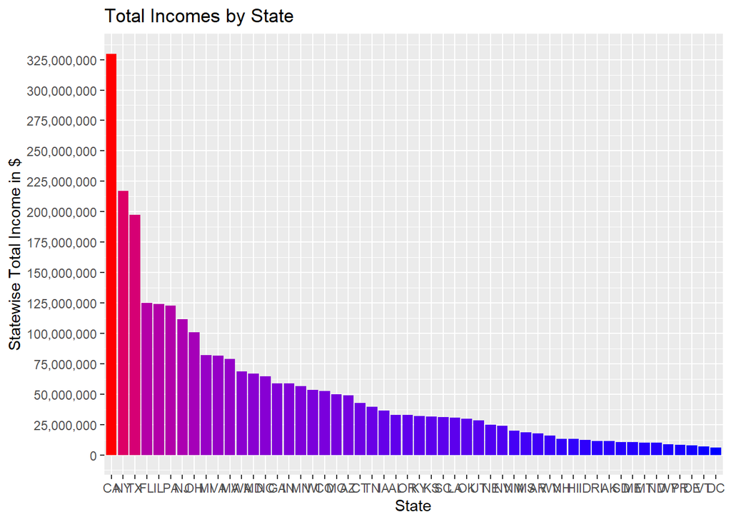

```r
##########################
# Statewise Total Incomes#
##########################

NewEngland<-state_data%>%
  select(State_ab,County,City,region,Median)%>%
  group_by(region == "NewEngland",State_ab)

NewEngland%>%
  group_by(State_ab)%>%
  summarise(total=sum(Median)) -> NewEnglandSummary


ggplot(NewEnglandSummary, aes(x =reorder(State_ab,desc(total)),
                       y=total,
                       fill=total)) +
  geom_bar(stat="identity", show.legend = FALSE)+
  scale_y_continuous(n.breaks = 16, labels=scales::comma) +
  scale_fill_gradient(low="blue", high="red") +
  xlab("State") + ylab("Statewise Total Income in $") +
  ggtitle("Total Incomes by State")
```

#### 7.1) Grouping US States by Avg Median Income

Summarising US Regions by Average Median Income helps us understand which portions of the US are earning higher on average.

The results are discussed below:

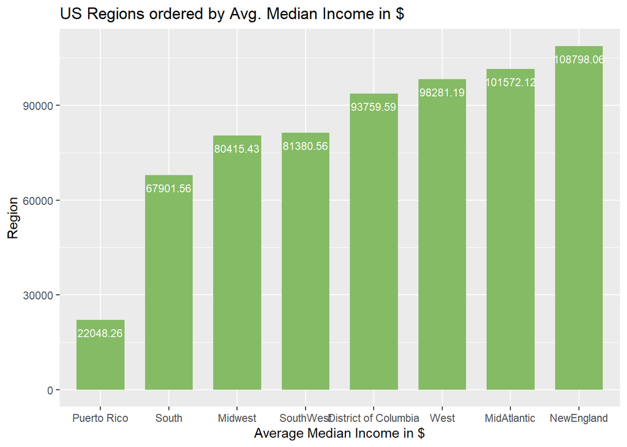

```r
#######################################
# Grouping US Regions by Median Income#
#######################################

state_data%>%
  group_by(region)%>%
  summarise(AvgMedianInc = mean(Median))%>%
  ggplot(mapping = aes(x=AvgMedianInc, y=fct_reorder(region, AvgMedianInc))) +
  geom_bar(stat = "identity", width=0.7, show.legend = FALSE, fill = "#85bb65") +
  coord_flip() +
  geom_text(aes(label = round(AvgMedianInc, digits = 2)), vjust = 2,
            size = 3, color = "white") +
  xlab("Region") +
  ylab("Average Median Income in $") +
  ggtitle("US Regions ordered by Avg. Median Income in $")
```

#### 7.2) Discussion for New England States

We dive deeper to New England States to understand which states tend to outperform others on average.

The results are discussed below:

```r
###############
# NEW ENGLAND #
###############

# Filter observational rows for New England States
state_data%>%
  filter(region == "NewEngland")%>%
  group_by(State_Name, State_ab)%>%
  summarise(StateAvgInc = mean(Median))%>%
  arrange(desc(StateAvgInc)) -> NewEnglandData
# Show Data for New England States
head(NewEnglandData)
```

```
## # A tibble: 6 × 3
## # Groups:   State_Name [6]
##   State_Name    State_ab StateAvgInc
##   <chr>         <chr>          <dbl>
## 1 Connecticut   CT           120557.
## 2 Massachusetts MA           118008.
## 3 Rhode Island  RI           105752.
## 4 New Hampshire NH           101146.
## 5 Vermont       VT            81113.
## 6 Maine         ME            66041.
```

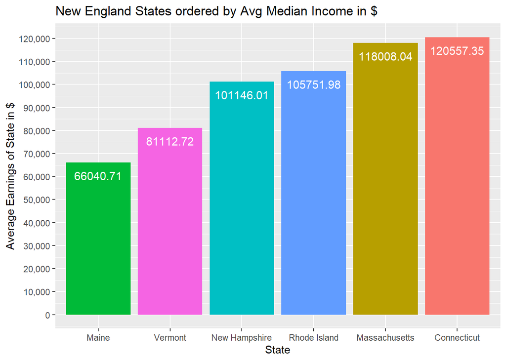

```r
# Plot New England States based on Avg Median Income
ggplot(NewEnglandData, mapping = aes(x = reorder(State_Name, StateAvgInc),
                                     y = StateAvgInc,
                                     fill = State_ab)) +
  geom_bar(stat="identity", show.legend = FALSE) +
  scale_y_continuous(n.breaks = 16, labels=scales::comma) +
  geom_text(aes(label = round(StateAvgInc, digits = 2)), vjust = 2,
            size = 4, color = "white") +
  xlab("State") +
  ylab("Average Earnings of State in $") +
  ggtitle("New England States ordered by Avg Median Income in $")
```

**Connecticut** and **Massachusetts** dominate the households with higher average incomes since these states have the highest concentration of capital and industries whereas the likes of Rhode Island, Vermont, New Hampshire and Maine rely on income from tourism which is seasonal.

#### 7.3) Discussion for Mid Atlantic States

Checking which Mid Atlantic States tend to outperform other states on average.

The results are discussed below:

```r
################
# MID ATLANTIC #
################

# Filter observational rows for only Mid Atlantic States
state_data%>%
  filter(region == "MidAtlantic")%>%
  group_by(State_Name, State_ab)%>%
  summarise(StateAvgInc = mean(Median))%>%
  arrange(desc(StateAvgInc)) -> MidAtlanticData
# Display first six rows of filtered data
head(MidAtlanticData)
```

```
## # A tibble: 6 × 3
## # Groups:   State_Name [6]
##   State_Name   State_ab StateAvgInc
##   <chr>        <chr>          <dbl>
## 1 New Jersey   NJ           125686.
## 2 Maryland     MD           113988.
## 3 Virginia     VA           103972.
## 4 New York     NY           100544.
## 5 Delaware     DE            87086.
## 6 Pennsylvania PA            83215.
```

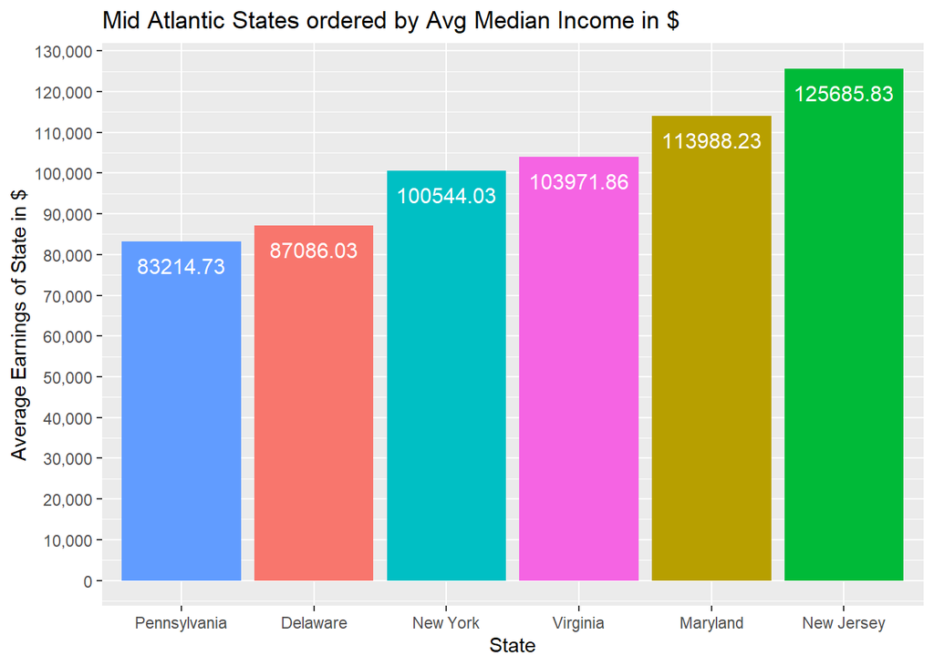

```r
# Plot states in Mid Atlantic region by Avg Median Income
ggplot(MidAtlanticData, mapping = aes(x = reorder(State_Name, StateAvgInc),
                                     y = StateAvgInc,
                                     fill = State_ab)) +
  geom_bar(stat="identity", show.legend = FALSE) +
  scale_y_continuous(n.breaks = 16, labels=scales::comma) +
  geom_text(aes(label = round(StateAvgInc, digits = 2)), vjust = 2,
            size = 4, color = "white") +
  xlab("State") +
  ylab("Average Earnings of State in $") +
  ggtitle("Mid Atlantic States ordered by Avg Median Income in $")
```

**New Jersey** and **Maryland** dominate the households with higher average incomes but the distribution of household income remains relatively uniform.

#### 7.3) Discussion for Southern States

The results are discussed below:

```r
################
# SOUTH REGION #
################

# Filter observational rows for Southern States
state_data%>%
  filter(region == "South")%>%
  group_by(State_Name, State_ab)%>%
  summarise(StateAvgInc = mean(Median))%>%
  arrange(desc(StateAvgInc)) -> SouthData
# Display first 6 rows
head(SouthData)
```

```
## # A tibble: 6 × 3
## # Groups:   State_Name [6]
##   State_Name     State_ab StateAvgInc
##   <chr>          <chr>          <dbl>
## 1 Florida        FL            75204.
## 2 Georgia        GA            71669.
## 3 Missouri       MO            70934.
## 4 North Carolina NC            70693.
## 5 South Carolina SC            68207.
## 6 Tennessee      TN            65055.
```

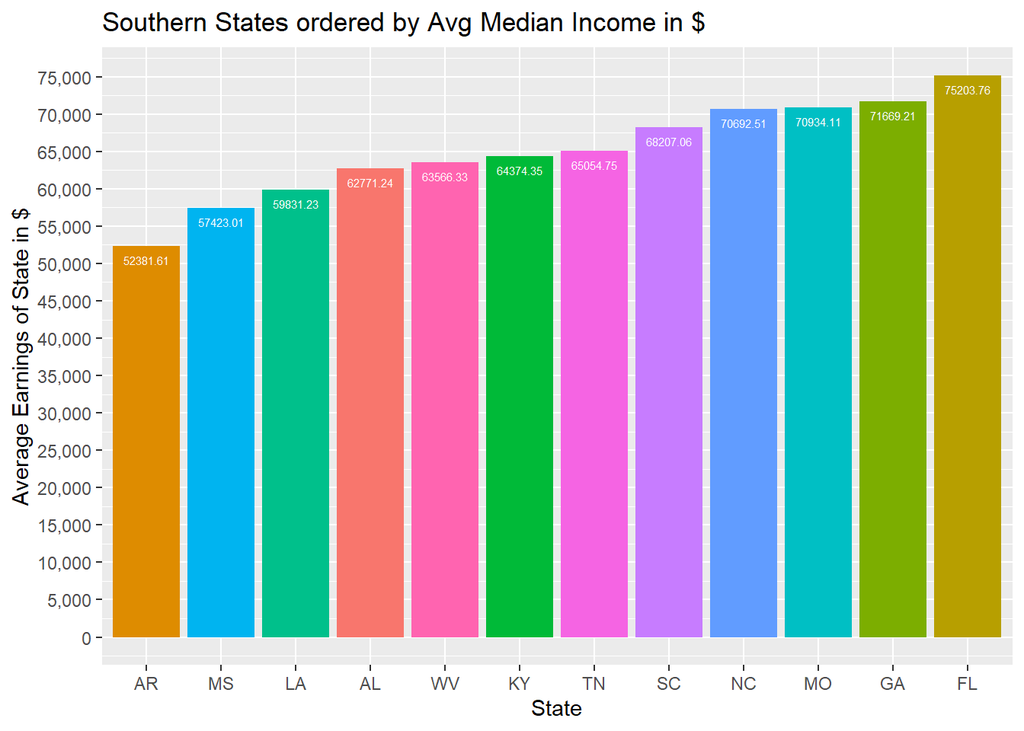

```r
# Plot southern states by Avg Median Income
ggplot(SouthData, mapping = aes(x = reorder(State_ab, StateAvgInc),
                                y = StateAvgInc,
                                fill = State_ab)) +
  geom_bar(stat="identity", show.legend = FALSE) +
  scale_y_continuous(n.breaks = 16, labels=scales::comma) +
  geom_text(aes(label = round(StateAvgInc, digits = 2)), vjust = 2,
            size = 2, color = "white") +
  xlab("State") +
  ylab("Average Earnings of State in $") +
  ggtitle("Southern States ordered by Avg Median Income in $")
```

**Florida** and **Georgia** dominate the households with higher average incomes but the distribution of household income remains relatively uniform.

### State-wise Analysis

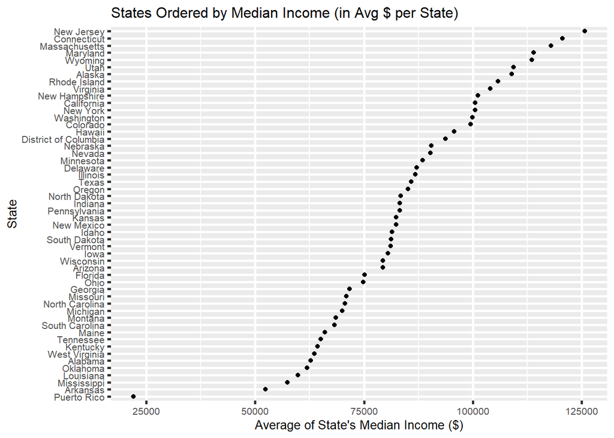

```r
############################################
# Grouping States by Average Median Income #
############################################

dataset%>%
  group_by(State_Name)%>%
  summarise(AvgMedians = mean(Median))%>%
  ggplot(mapping=aes(x=AvgMedians, y= fct_reorder(State_Name, AvgMedians))) +
  geom_point() +
  xlab("Average of State's Median Income ($)") +
  ylab("State") +
  ggtitle("States Ordered by Median Income (in Avg $ per State)") +
  theme(text = element_text(size = 10), element_line(size = 1))
```

#### 8.1) Analysis for New York State

BY further looking at NY Counties, we can begin to analyze which counties perform better and plot them geographically to realize where high earning clusters lie.

```r
###############################
# Analysis for New York State #
###############################

# Subset the dataset using dplyr to obtain rows for New York
dataset%>%
  filter(State_ab == "NY") -> datasetNY
# Display first six rows
head(datasetNY)
```

```
##         id State_Code State_Name State_ab           County       City
## 1 36011353         36   New York       NY Jefferson County      Adams
## 2 36011363         36   New York       NY   Genesee County  Alexander
## 3 36011373         36   New York       NY  Dutchess County     Amenia
## 4 36011383         36   New York       NY     Tioga County  Apalachin
## 5 36011393         36   New York       NY    Nassau County  Hempstead
## 6 36011403         36   New York       NY  Chenango County Bainbridge
##            Place    Type Primary Zip_Code Area_Code   ALand  AWater      Lat
## 1          Adams Village   place    13605       315 3742271       0 43.81022
## 2      Alexander Village   place    14005       585 1132465       0 42.90202
## 3         Amenia     CDP   place    12501       845 3152792   70626 41.84820
## 4      Apalachin     CDP   place    13732       607 3779536       0 42.07057
## 5 Atlantic Beach Village   place    11550       516 1136400 1554299 40.58801
## 6     Bainbridge Village   place    13733       607 3403618  102212 42.30170
##         Lon   Mean Median Stdev     sum_w
## 1 -76.02298  54499  37697 48943 470.57926
## 2 -78.25911  64770  57765 40606  91.79536
## 3 -73.55558  82188  56048 67388 245.05769
## 4 -76.16264  73219  54363 55251 311.05540
## 5 -73.72936 131519 114157 78333 183.38286
## 6 -75.47888  52841  44096 42015 348.18708
```

```r
# Summarise the NY Data based on Latitudes, Longitudes and Average Income
# for the top 10 earning counties
datasetNY%>%
  group_by(County)%>%
  summarise(AvgLat = mean(Lat),
            AvgLon = mean(Lon),
            AvgInc = median(Median))%>%
  arrange(desc(AvgInc))%>%
  slice(1:10) -> sumdatasetNY


# Display first six rows of NY Data
head(sumdatasetNY)
```

```
## # A tibble: 6 × 4
##   County             AvgLat AvgLon  AvgInc
##   <chr>               <dbl>  <dbl>   <dbl>
## 1 Essex County         44.1  -73.5 300000
## 2 Ontario County       42.8  -77.5 300000
## 3 Schenectady County   42.8  -74.1 300000
## 4 Putnam County        41.4  -73.7 196376
## 5 Rensselaer County    42.6  -73.6 182219
## 6 Westchester County   41.0  -73.8 137484.
```

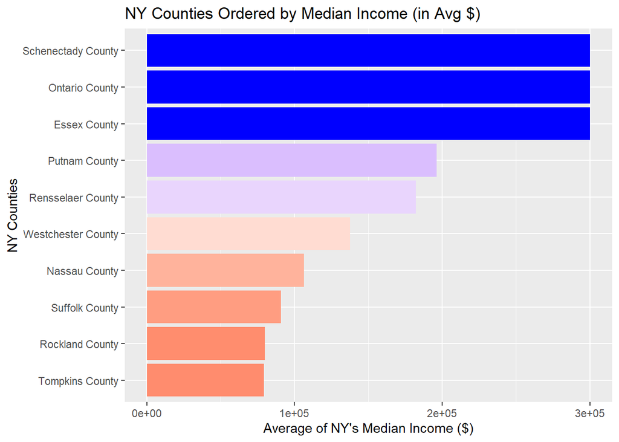

```r
# Plot the Avg. Median Income for each county in NY in descending order
sumdatasetNY%>%
  ggplot(mapping=aes(x=AvgInc, y= fct_reorder(County, AvgInc), fill= AvgInc)) +
  geom_bar(stat="identity", show.legend = FALSE) +
  scale_fill_gradient2(high = 'blue', mid = 'snow', low = 'red',
                       midpoint = median(sumdatasetNY$AvgInc)) +
  xlab("Average of NY's Median Income ($)") +
  ylab("NY Counties") +
  ggtitle("NY Counties Ordered by Median Income (in Avg $)")
```

```r
# Plot the counties on a map with markers to indicate highest earning counties
mapview(sumdatasetNY, xcol = "AvgLon", ycol = "AvgLat", crs = 4269, grid=FALSE,
        cex = "AvgInc", burst=TRUE, legend = TRUE)
```

[interactive chart not shown]

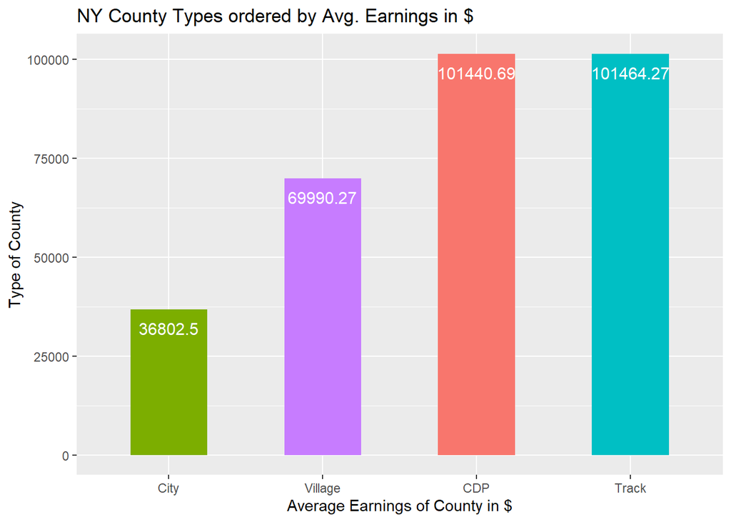

```r
# Plot earnings by Type of location
datasetNY%>%
  group_by(Type)%>%
  summarise(AvgEarnings = mean(Median))%>%
  arrange(desc(AvgEarnings))%>%
  ggplot(mapping=aes(x=AvgEarnings, y=fct_reorder(Type, AvgEarnings),
                     fill = Type)) +
  geom_bar(stat = "identity",width=0.5, show.legend = FALSE) + coord_flip() +
  geom_text(aes(label = round(AvgEarnings, digits = 2)), vjust = 2,
            size = 4, color = "white") +
  xlab("Type of County") +
  ylab("Average Earnings of County in $") +
  ggtitle("NY County Types ordered by Avg. Earnings in $")
```

#### 8.2) Analysis for Maine State

BY further looking at ME Counties, we can begin to analyze which counties perform better and plot them geographically to realize where high earning clusters lie.

```r
############################
# Analysis for Maine State #
############################

# Subset the dataset using dplyr to obtain rows for Maine
dataset%>%
  filter(State_ab == "ME") -> datasetME
# Display first six rows
head(datasetME)
```

```
##        id State_Code State_Name State_ab            County             City
## 1 2301139         23      Maine       ME    Hancock County       Bar Harbor
## 2 2301149         23      Maine       ME  Penobscot County           Brewer
## 3 2301159         23      Maine       ME    Hancock County          Castine
## 4 2301169         23      Maine       ME  Penobscot County East Millinocket
## 5 2301179         23      Maine       ME Cumberland County         Freeport
## 6 2301189         23      Maine       ME  Aroostook County          Houlton
##              Place Type Primary Zip_Code Area_Code    ALand  AWater      Lat
## 1       Bar Harbor  CDP   place    04609       207  8223821       0 44.38131
## 2      Brewer city City   place    04412       207 39455700 1168416 44.78475
## 3          Castine  CDP   place    04421       207  3993192   16201 44.39398
## 4 East Millinocket  CDP   place    04430       207  2476883       0 45.62605
## 5         Freeport  CDP   place    04032       207  4443770       0 43.85705
## 6          Houlton  CDP   place    04730       207 13609941       0 46.12148
##         Lon  Mean Median Stdev     sum_w
## 1 -68.21113 50330  44542 40817  802.1965
## 2 -68.73501 63940  51916 51668 2344.3599
## 3 -68.80602 69293  42793 60671  118.8619
## 4 -68.57409 44532  35405 35040  520.0397
## 5 -70.10259 75810  57158 67688  349.3177
## 6 -67.83218 41638  31718 37388 1653.6826
```

```r
# Summarise the NY Data based on Latitudes, Longitudes and Average Income
# for the top earning counties
datasetME%>%
  group_by(County)%>%
  summarise(AvgLat = mean(Lat),
            AvgLon = mean(Lon),
            AvgInc = median(Median))%>%
  arrange(desc(AvgInc))-> sumdatasetME

# Display first six rows of ME Data
head(sumdatasetME)
```

```
## # A tibble: 6 × 4
##   County              AvgLat AvgLon AvgInc
##   <chr>                <dbl>  <dbl>  <dbl>
## 1 Cumberland County     43.8  -70.3 61597
## 2 Androscoggin County   44.4  -69.7 47224
## 3 Kennebec County       44.2  -69.8 46976
## 4 Hancock County        44.4  -68.5 43668.
## 5 Penobscot County      45.2  -68.7 43660.
## 6 Aroostook County      46.1  -67.8 31718
```

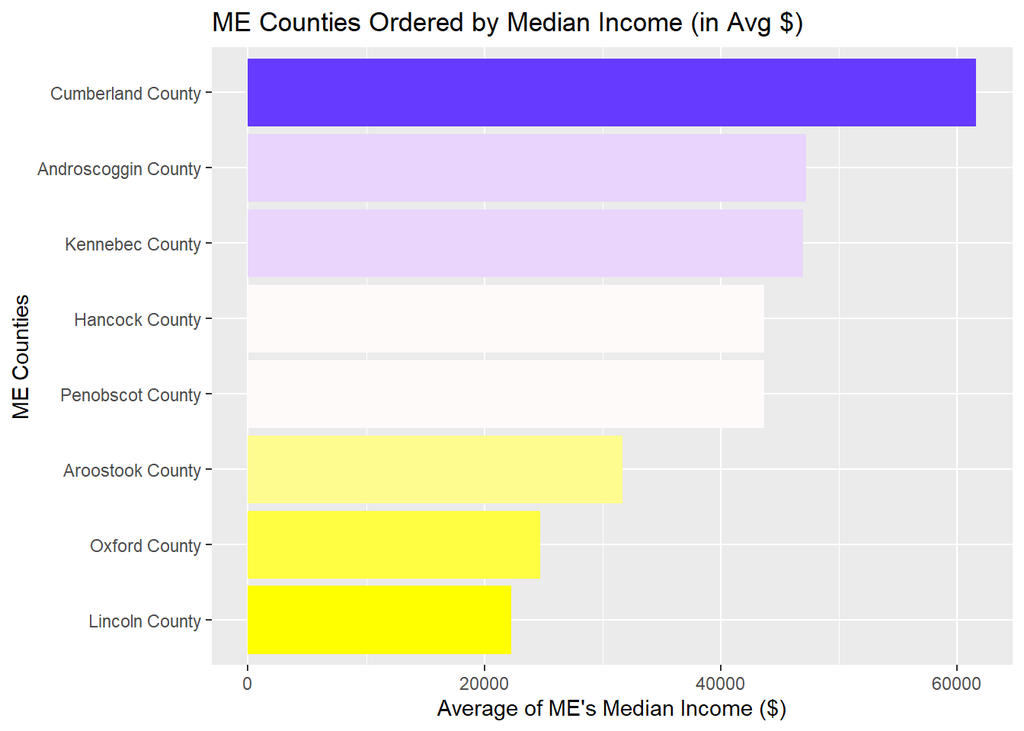

```r
# Plot the Avg. Median Income for each county in ME in descending order
sumdatasetME%>%
  ggplot(mapping=aes(x=AvgInc, y= fct_reorder(County, AvgInc), fill= AvgInc)) +
  geom_bar(stat="identity", show.legend = FALSE) +
  scale_fill_gradient2(high = 'blue', mid = 'snow', low = 'yellow',
                       midpoint = median(sumdatasetME$AvgInc)) +
  xlab("Average of ME's Median Income ($)") +
  ylab("ME Counties") +
  ggtitle("ME Counties Ordered by Median Income (in Avg $)")
```

```r
# Plot the counties on a map with markers to indicate highest earning counties
mapview(sumdatasetME, xcol = "AvgLon", ycol = "AvgLat", crs = 4269, grid=FALSE,
        cex = "AvgInc", burst=TRUE, legend = TRUE)
```

[interactive chart not shown]

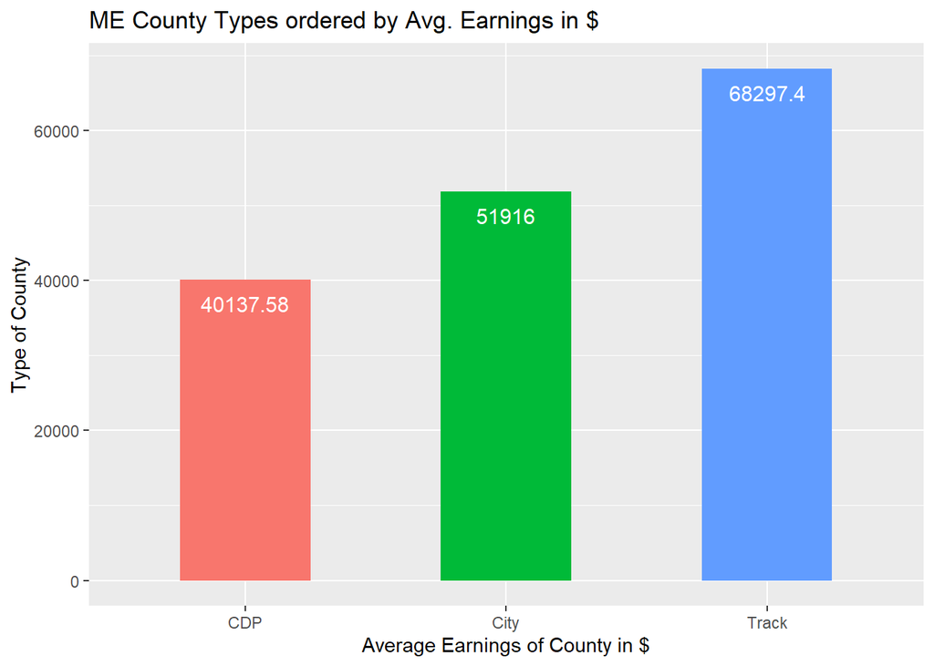

```r
# Plot earnings by Type of location
datasetME%>%
  group_by(Type)%>%
  summarise(AvgEarnings = mean(Median))%>%
  arrange(desc(AvgEarnings))%>%
  ggplot(mapping=aes(x=AvgEarnings, y=fct_reorder(Type, AvgEarnings),
                     fill = Type)) +
  geom_bar(stat = "identity",width=0.5, show.legend = FALSE) + coord_flip() +
  geom_text(aes(label = round(AvgEarnings, digits = 2)), vjust = 2,
            size = 4, color = "white") +
  xlab("Type of County") +
  ylab("Average Earnings of County in $") +
  ggtitle("ME County Types ordered by Avg. Earnings in $")
```

#### 8.3) Analysis for Texas State

BY further looking at TX Counties, we can begin to analyze which counties perform better and plot them geographically to realize where high earning clusters lie.

```r
############################
# Analysis for Texas State #
############################

# Subset the dataset using dplyr to obtain rows for Maine
dataset%>%
  filter(State_ab == "TX") -> datasetTX
# Display first six rows
head(datasetTX)
```

```
##         id State_Code State_Name State_ab             County            City
## 1 48012310         48      Texas       TX      Oldham County          Adrian
## 2 48012320         48      Texas       TX Shackelford County          Albany
## 3 48012330         48      Texas       TX       Starr County Rio Grande City
## 4 48012340         48      Texas       TX     Liberty County         Liberty
## 5 48012350         48      Texas       TX      Parker County           Aledo
## 6 48012360         48      Texas       TX      Nueces County    Aransas Pass
##                 Place Type Primary Zip_Code Area_Code    ALand    AWater
## 1         Adrian city City   place    79001       806  1217792         0
## 2         Albany city City   place    76430       325  4057164         0
## 3 Alto Bonito Heights  CDP   place    78582       956   133278         0
## 4           Ames city City   place    77575       936  8554449         0
## 5             Annetta Town   place    76008       817  6011871    155233
## 6   Aransas Pass city City   place    78336       361 32555415 103269756
##        Lat        Lon   Mean Median Stdev     sum_w
## 1 35.27412 -102.66725  72707  44340 78512  48.73143
## 2 32.72727  -99.29566  51581  50345 39442 567.66726
## 3 26.31578  -98.64133  13908  16450  6008  40.33147
## 4 30.04508  -94.73732  49157  29869 48967 272.66063
## 5 32.69619  -97.66330 126397 120366 68183 140.12267
## 6 27.89021  -97.11847      0      0     0   0.00000
```

```r
# Summarise the TX Data based on Latitudes, Longitudes and Average Income
# for the top earning counties
datasetTX%>%
  group_by(County)%>%
  summarise(AvgLat = mean(Lat),
            AvgLon = mean(Lon),
            AvgInc = median(Median))%>%
  slice(1:15)%>%
  arrange(desc(AvgInc))-> sumdatasetTX

# Display first six rows of TX Data
head(sumdatasetTX)
```

```
## # A tibble: 6 × 4
##   County         AvgLat AvgLon AvgInc
##   <chr>           <dbl>  <dbl>  <dbl>
## 1 Austin County    29.8  -96.0 300000
## 2 Bastrop County   30.1  -97.5 300000
## 3 Bee County       28.2  -97.7 300000
## 4 Camp County      33.0  -95.0 300000
## 5 Bexar County     29.5  -98.5  82298
## 6 Bell County      30.9  -97.5  82273
```

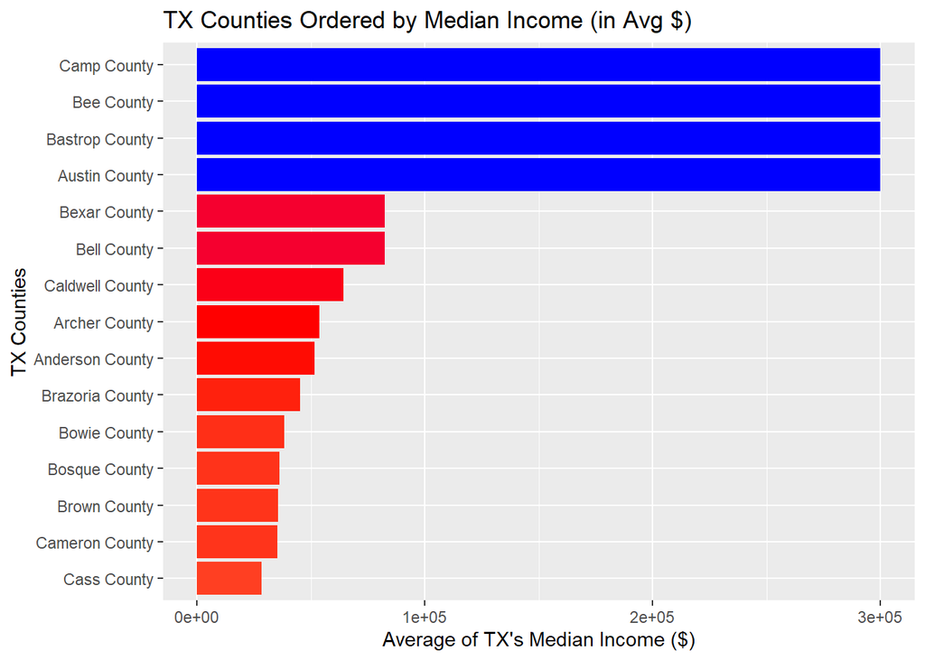

```r
# Plot the Avg. Median Income for each county in TX in descending order
sumdatasetTX%>%
  ggplot(mapping=aes(x=AvgInc, y= fct_reorder(County, AvgInc), fill= AvgInc)) +
  geom_bar(stat="identity", show.legend = FALSE) +
  scale_fill_gradient2(high = 'blue', mid = 'red', low = 'white',
                       midpoint = median(sumdatasetTX$AvgInc)) +
  xlab("Average of TX's Median Income ($)") +
  ylab("TX Counties") +
  ggtitle("TX Counties Ordered by Median Income (in Avg $)")
```

```r
# Plot the counties on a map with markers to indicate highest earning counties
mapview(sumdatasetTX, xcol = "AvgLon", ycol = "AvgLat", crs = 4269, grid=FALSE,
        cex = "AvgInc", burst=TRUE, legend = TRUE)
```

[interactive chart not shown]

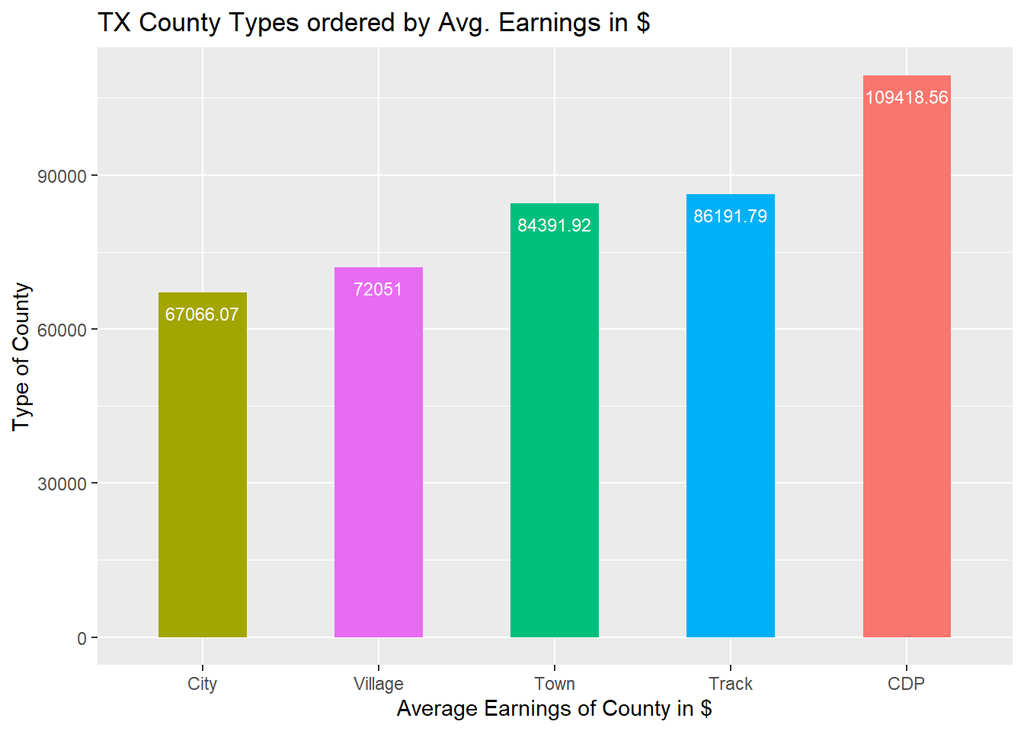

```r
# Plot earnings by Type of location
datasetTX%>%
  group_by(Type)%>%
  summarise(AvgEarnings = mean(Median))%>%
  arrange(desc(AvgEarnings))%>%
  ggplot(mapping=aes(x=AvgEarnings, y=fct_reorder(Type, AvgEarnings),
                     fill = Type)) +
  geom_bar(stat = "identity",width=0.5, show.legend = FALSE) + coord_flip() +
  geom_text(aes(label = round(AvgEarnings, digits = 2)), vjust = 2,
            size = 3, color = "white") +
  xlab("Type of County") +
  ylab("Average Earnings of County in $") +
  ggtitle("TX County Types ordered by Avg. Earnings in $")
```

### Regression Analysis

Regression Analysis is used to fit the data for a given dependent variable in terms of the other independent variables to estimate values of the dependent variable given the other parameters.

We have employed the fastDummies library to initially convert qualitative information into a set of dummy variables (0/1) to indicate the absence or presence of a quality respectively.

We have then performed Regression analysis using Median as the dependent variable.

```r
# Reading updated dataset
regdata<-read.csv("regdata.csv")
# Replacing qualitative variables with dummy data
dumdata<-dummy_cols(regdata,select_columns = c("County","State_Name","Type"))
# Generating Regression Model with Median income as dependent variable
MLRmodel <- lm(Median ~ State_Name + Type + ALand, data=dumdata)
# Summary Results for Regression
summary(MLRmodel)
```

```
##
## Call:
## lm(formula = Median ~ State_Name + Type + ALand, data = dumdata)
##
## Residuals:
##     Min      1Q  Median      3Q     Max
## -146327  -46995  -28867   -3706  277439
##
## Coefficients:
##                                  Estimate Std. Error t value Pr(>|t|)
## (Intercept)                     4.500e+04  8.646e+03   5.205 1.95e-07 ***
## State_NameAlaska                5.707e+04  9.535e+03   5.986 2.17e-09 ***
## State_NameArizona               1.404e+04  5.100e+03   2.754 0.005892 **
## State_NameArkansas             -9.081e+03  5.975e+03  -1.520 0.128520
## State_NameCalifornia            3.576e+04  4.038e+03   8.855  < 2e-16 ***
## State_NameColorado              3.561e+04  5.295e+03   6.726 1.77e-11 ***
## State_NameConnecticut           5.608e+04  5.901e+03   9.504  < 2e-16 ***
## State_NameDelaware              2.405e+04  9.888e+03   2.432 0.015013 *
## State_NameDistrict of Columbia  2.967e+04  1.137e+04   2.610 0.009046 **
## State_NameFlorida               1.036e+04  4.300e+03   2.410 0.015970 *
## State_NameGeorgia               8.570e+03  4.800e+03   1.785 0.074200 .
## State_NameHawaii                2.868e+04  8.217e+03   3.490 0.000483 ***
## State_NameIdaho                 2.030e+04  7.973e+03   2.546 0.010902 *
## State_NameIllinois              2.378e+04  4.394e+03   5.411 6.31e-08 ***
## State_NameIndiana               1.973e+04  4.950e+03   3.986 6.74e-05 ***
## State_NameIowa                  2.052e+04  5.521e+03   3.717 0.000202 ***
## State_NameKansas                2.164e+04  5.786e+03   3.740 0.000185 ***
## State_NameKentucky              1.105e+03  5.374e+03   0.206 0.837020
## State_NameLouisiana            -4.431e+03  5.335e+03  -0.831 0.406185
## State_NameMaine                 2.109e+02  7.812e+03   0.027 0.978457
## State_NameMaryland              4.831e+04  5.161e+03   9.361  < 2e-16 ***
## State_NameMassachusetts         5.308e+04  5.007e+03  10.602  < 2e-16 ***
## State_NameMichigan              6.225e+03  4.510e+03   1.380 0.167532
## State_NameMinnesota             2.692e+04  5.059e+03   5.322 1.04e-07 ***
## State_NameMississippi          -5.815e+03  6.080e+03  -0.956 0.338924
## State_NameMissouri              9.071e+03  4.957e+03   1.830 0.067282 .
## State_NameMontana               3.138e+03  8.015e+03   0.391 0.695430
## State_NameNebraska              2.931e+04  6.424e+03   4.562 5.08e-06 ***
## State_NameNevada                2.559e+04  6.472e+03   3.954 7.70e-05 ***
## State_NameNew Hampshire         3.587e+04  8.385e+03   4.278 1.89e-05 ***
```

[output cut: 23 more lines]

```
## TypeCity                        1.403e+02  8.260e+03   0.017 0.986450
## TypeCommunity                   1.015e+04  2.215e+04   0.458 0.646901
## TypeCounty                     -1.053e+04  6.131e+04  -0.172 0.863649
## TypeMunicipality                7.203e+03  8.617e+04   0.084 0.933388
## TypeTown                        5.625e+03  8.776e+03   0.641 0.521550
## TypeTrack                       1.940e+04  7.791e+03   2.490 0.012791 *
## TypeUrban                       1.554e+04  3.166e+04   0.491 0.623456
## TypeVillage                     6.317e+03  8.976e+03   0.704 0.481634
## ALand                          -1.963e-06  3.902e-07  -5.032 4.89e-07 ***
## ---
## Signif. codes:  0 '***' 0.001 '**' 0.01 '*' 0.05 '.' 0.1 ' ' 1
##
## Residual standard error: 85840 on 32464 degrees of freedom
## Multiple R-squared:  0.04627,    Adjusted R-squared:  0.04448
## F-statistic: 25.82 on 61 and 32464 DF,  p-value: < 2.2e-16
```

Regression analysis reveals that a State’s Type and Area of Land play a minimal role in determining Median Income.

We would require household incomes, industry types and migration details to conduct a more successful analysis using more powerful algorithms.

### Conclusion

By analyzing US household incomes, we have identified the top performing regions as the *New England* and *Mid Atlantic* regions.

Mid Atlantic and Southern States show a more even distribution of household median income.

Conducting a more in-depth analysis for individual states (NY, ME and TX), we could identify clusters where there are high earning counties which can be beneficial for city planners, real estate developers or out-of-state migrants hoping to move into a particular region.

While Regression Analysis could not reveal further insight, we hope that in the future, with details for households and industries that we can employ more powerful analysis techniques.